# Intro_Raster_Data

### GeoTIFF

GeoTIFF is a public domain metadata standard which allows georeferencing information to be embedded within a TIFF file. The potential additional information includes map projection, coordinate systems, ellipsoids, datums, and everything else necessary to establish the exact spatial reference for the file. GeoTIFF is widely supported by image-processing applications, GIS, and other geospatial software tools.

Here are the key characteristics of a GeoTIFF file:

- **TIFF**: The base file format is TIFF (Tagged Image File Format), which is a flexible, adaptable file format for handling images and data within a single file.
- **GeoTags**: GeoTIFF uses a set of TIFF tags to describe "Cartographic" information associated with TIFF imagery that originates from satellite imaging systems, scanned aerial photography, scanned maps, digital elevation models, or as a result of geographic analyses.
- **Data Types**: It can store imagery in various data types, from simple binary images to complex multi-band floating-point data.
- **Compression**: TIFF allows for various compression techniques, which can also be used in GeoTIFF to reduce file size.

A typical GeoTIFF file includes the following components:

1. **Raster Data**: The image pixel values.
2. **Spatial Metadata**: Information about the geographic or projected coordinate system.
3. **GeoKeys**: A set of specific keys in the TIFF file's header that includes:
   - Model Type (Projected or Geographic)
   - Raster Type (Pixel or Point)
   - Geographic or Projected Coordinate System Definition
   - Datum
   - Projection Information (if the model type is projected)
   - Tie points and scale information or transformation matrix
   - Map units (e.g., meters, feet)
4. **Optional Metadata**: May include attribution data, such as the image's creation date, the author, or descriptions.

GeoTIFFs can be read and written by a wide variety of GIS applications. Python libraries such as `rasterio` and `GDAL` are commonly used to interact with GeoTIFF files programmatically.

The actual data structure within a GeoTIFF file is not easily displayed in a text-based format because it is binary and often quite large. However, when you open a GeoTIFF file in a GIS software program, you can access and visualize the spatial data and also view the metadata to understand the spatial reference information.

```python
import rasterio
filename = 'eko.tif'
data = rasterio.open(filename)
display(data)

from rasterio.plot import show
show(data,contour=False)
```

[output not shown]

# Introduction to Understanding Rasterio

Rasterio is an open-source Python library that allows users to read, write, and manipulate raster datasets. It is designed to make working with geospatial raster data more efficient and straightforward. Built on top of the GDAL (Geospatial Data Abstraction Library), Rasterio inherits its ability to handle a wide variety of raster formats, including GeoTIFF.

## Overview of Rasterio

Rasterio employs Pythonic idioms and structures, making it easier to read and write raster data compared to the more verbose GDAL Python bindings. It integrates well with other scientific Python libraries like NumPy for numerical computations and Matplotlib for plotting.

### Key Features:

- **Read and write**: Supports various raster formats, with a focus on GeoTIFF.
- **Pythonic interface**: Simplifies the process of reading and writing raster data in Python.
- **Geospatial operations**: Includes functions for raster transformations, reprojections, and more.
- **Integration**: Works well with other libraries such as Numpy and Matplotlib.

## Reading Raster Files

Using Rasterio to read raster data involves opening the dataset and then reading it as arrays:

- **Open Dataset**: Rasterio opens a connection to the raster file, which can be read or written to.
- **Read Data**: Data can be read as NumPy arrays, which can be processed with the power of Python.

```
import rasterio

with rasterio.open('example.tif') as src:
    data = src.read(1)  # Read first band
```

## Raster Data Structure

When you load raster data using Rasterio, you have access to:

- **Bands**: Raster datasets can have one or more bands, which can be read individually.
- **Metadata**: Contains information like the data type, dimensions, and georeferencing information.
- **Profiles**: A profile is a collection of metadata that defines how a dataset should be stored.

## Sources

- Gillies, S., et al. (2013). Rasterio: Geospatial raster I/O for Python programmers. GitHub repository. [Rasterio GitHub](https://github.com/mapbox/rasterio)
  - The official Rasterio GitHub repository contains the source code, examples, and issues where users can contribute and seek help.
- GDAL/OGR contributors (2023). GDAL/OGR Geospatial Data Abstraction software Library. [GDAL/OGR](https://gdal.org/)
  - As Rasterio is built on top of GDAL, the GDAL documentation is a valuable resource for understanding the foundations of Rasterio's functionality.

By leveraging Rasterio's capabilities, geoscientists and GIS professionals can efficiently handle large and complex raster datasets within the Python ecosystem, streamlining the process of geospatial data analysis.

# Digital Elevation Models (DEMs) and RichDEM

Digital Elevation Models (DEMs) are a fundamental type of geospatial data used to represent the Earth's terrain surfaces. DEMs consist of a grid of cells or pixels where each pixel contains an elevation value. RichDEM is a high-performance software library that processes DEMs, providing tools for terrain analysis and hydrological modeling.

## Understanding Digital Elevation Models (DEMs)

DEMs are created from terrain elevation data and serve as a crucial dataset in various geospatial analyses, including:

- **Hydrological modeling:** DEMs are used to delineate watersheds and predict water flow paths.
- **Infrastructure planning:** Elevation data is essential in planning road gradients and building locations.
- **Environmental science:** DEMs help model ecosystems, study soil erosion, and assess flood risk.

### Characteristics of DEMs:

- **Resolution:** The spatial resolution of a DEM determines the size of the surface area that each pixel covers. High-resolution DEMs provide more detail but require more storage space and processing power.
- **Accuracy:** Elevation accuracy is vital for many analyses. Accuracy can be affected by the method of data collection (e.g., LiDAR, photogrammetry, GPS).
- **Format:** DEMs can be stored in various formats, with GeoTIFF being a common choice due to its ability to store georeferencing information.

## Introduction to RichDEM

RichDEM is a library specializing in high-performance analysis of DEMs. It offers a variety of algorithms optimized for operations such as:

- **Flow accumulation:** Determines how much water flows through each cell in a raster.
- **Slope and aspect:** Calculates the steepness and direction of each cell's slope.
- **Depression analysis:** Identifies and fills depressions in DEMs for hydrological modeling.

RichDEM's operations are typically faster and more memory-efficient than those found in other libraries, making it well-suited for large or complex datasets.

### Using RichDEM:

RichDEM provides a Python interface to leverage its capabilities. To use RichDEM, you would typically:

1. Load your DEM using a library like `rasterio`.
2. Pass the DEM's numpy array to RichDEM for processing.
3. Use RichDEM's functions to calculate terrain attributes.

```
import rasterio
import richdem as rd

with rasterio.open('dem.tif') as src:
    dem_array = src.read(1)  # Read first band as numpy array
    rdarray = rd.rdarray(dem_array, no_data=-9999)  # Convert to RichDEM array
    slope = rd.TerrainAttribute(rdarray, attrib='slope_degrees')
```

## Sources

- Lindsay, J. B. (2016). Whitebox GAT: A case study in geomorphometric analysis. Computers & Geosciences.
  - Discusses geomorphometric analysis, which is closely related to DEM analysis.
- Lindsay, J. B. (2016). RichDEM: Terrain Analysis Software. [RichDEM GitHub](https://github.com/r-barnes/richdem)
  - The official RichDEM GitHub repository, containing the source code and documentation.
- Wechsler, S. P. (2007). Uncertainties associated with digital elevation models for hydrologic applications: a review. Hydrology and Earth System Sciences.

# Raster Data Manipulation

Manipulating raster data is a central task in geospatial analysis, allowing scientists to derive new information, make predictions, and model spatial phenomena. This section delves into the techniques and considerations involved in raster data manipulation.

## Fundamentals of Raster Data Manipulation

Raster data manipulation involves altering or analyzing raster images to suit specific objectives. These objectives can range from changing the spatial resolution of an image to calculating new data layers based on existing ones.

### Operations in Raster Data Manipulation:

- **Band Arithmetic:** Involves performing mathematical operations on the raster bands to derive new layers (e.g., NDVI for vegetation analysis).
- **Resampling:** Changing the pixel size of a raster image, which can be used to match the resolution of another dataset or to downscale/up-scale data for analysis.
- **Reprojection:** Involves changing the coordinate system of a raster dataset to align with other data layers or to match a required coordinate system for analysis or display.
- **Masking:** Using a shape or boundary to extract or remove parts of a raster, often to focus on a region of interest or to remove irrelevant data.

## Techniques and Tools

Modern GIS software and spatial libraries provide robust tools for raster data manipulation. Python libraries, such as Rasterio, are particularly useful due to their integration with other scientific libraries.

### Example of Raster Data Manipulation with Python:

```
import rasterio
from rasterio.warp import calculate_default_transform, reproject, Resampling

# Open the original raster file
with rasterio.open('original.tif') as src:
    # Define the new CRS
    new_crs = 'EPSG:4326'  # WGS84
    transform, width, height = calculate_default_transform(
        src.crs, new_crs, src.width, src.height, *src.bounds)
    kwargs = src.meta.copy()
    kwargs.update({
        'crs': new_crs,
        'transform': transform,
        'width': width,
        'height': height
    })

    # Reproject and resample the raster dataset
    with rasterio.open('reprojected.tif', 'w', **kwargs) as dst:
        for i in range(1, src.count + 1):
            reproject(
                source=rasterio.band(src, i),
                destination=rasterio.band(dst, i),
                src_transform=src.transform,
                src_crs=src.crs,
                dst_transform=transform,
                dst_crs=new_crs,
                resampling=Resampling.nearest)
```

## Sources

- Neteler, M., Bowman, M. H., Landa, M., & Metz, M. (2012). GRASS GIS: A multi-purpose open source GIS. Environmental Modelling & Software.
  - The paper describes the GRASS GIS system which is well-known for its raster processing capabilities.
- Mitchell, A. (2005). The ESRI guide to GIS analysis, Volume 2: Spatial measurements and statistics. ESRI, Inc.
  - Provides an overview of GIS analysis including various spatial measurement and manipulation techniques for raster data.
- Rasterio documentation: https://rasterio.readthedocs.io/

# Raster Calculations

Raster calculations involve performing mathematical operations on raster data to create new raster layers that represent derived or analyzed data. This is fundamental in remote sensing and other geospatial analyses to extract meaningful information from raw data.

## Theoretical Background

The normalized difference vegetation index is a simple, but effective index for quantifying green vegetation. It is a measure of the state of vegetation health based on how plants reflect light at certain wavelengths. The value range of the NDVI is -1 to 1. Negative values of NDVI (values approaching -1) correspond to water. Values close to zero (-0.1to 0.1) generally correspond to barren areas of rock, sand, or snow. Low, positive values represent shrub and grassland (approximately 0.2 to 0.4), while high values indicate temperate and tropical rainforests (values approaching 1).

### Band Arithmetic

- **Definition:** Band arithmetic is a pixel-by-pixel calculation that involves one or more bands of a raster dataset. It’s commonly used in remote sensing to derive indices like NDVI (Normalized Difference Vegetation Index), which indicate vegetation health.
- **Formula for NDVI:** $ NDVI = \frac{(NIR - Red)}{(NIR + Red)} $
- **Importance:** NDVI is crucial for monitoring vegetation, assessing drought conditions, and planning agricultural activities.

### Raster Calculations in Python

Python's rasterio library can be used for raster calculations along with NumPy, which is highly optimized for numerical computations on multi-dimensional arrays.

## Practice Exercise

### Objective

To calculate the NDVI from a multi-band satellite image and visualize the results.

### Requirements

- A multi-band raster dataset with Red and Near-Infrared (NIR) bands (e.g., Landsat or Sentinel imagery). May be downloaded from: https://dataspace.copernicus.eu
- Python environment with rasterio and NumPy installed.

### Steps

1. **Read the Raster Data:**
   - Load the raster file with rasterio.
   - Read the specific bands required for NDVI (Red and NIR). For Landsat 8, bands 4 (Red) and 5 (NIR) are typically used. For Sentinel-2, bands 4 (Red) and 8 (NIR) are used.
2. **Perform NDVI Calculation:**
   - Use NumPy to perform array-based arithmetic to calculate NDVI.
   - Handle division by zero to avoid NaN values in the output.
3. **Visualize the Result:**
   - Use Matplotlib to visualize the NDVI raster.
   - Apply a colormap that highlights vegetation health (e.g., `plt.cm.Greens`).

### Example Python Code

```
import numpy as np
import rasterio
import matplotlib.pyplot as plt

# Step 1: Read the Raster Data
with rasterio.open('satellite_image_band4.jp2') as src:
    red_band = src.read(1)
with rasterio.open('satellite_image_band8.jp2') as src:
    nir_band = src.read(1)

# Step 2: Perform NDVI Calculation
# Prevent division by zero
with np.errstate(divide='ignore', invalid='ignore'):
    ndvi = (nir_band.astype(float) - red_band.astype(float)) / (nir_band + red_band)

# Step 3: Visualize the Result
plt.figure(figsize=(10, 6))
plt.imshow(ndvi, cmap='RdYlGn')
plt.colorbar(label='NDVI')
plt.title('NDVI Map')
plt.xlabel('Column #')
plt.ylabel('Row #')
plt.show()
```

### Exercise

1. Download the data from: https://gofile.me/79ARD/iXXxn7bq9
2. Visualize each band. Give comment!
3. Calculate NDVI and analyze!

### Citations and Sources

- Tucker, C. J. (1979). Red and photographic infrared linear combinations for monitoring vegetation. Remote Sensing of Environment.
  - Tucker's paper introduces NDVI and discusses its applications and importance.
- Rasterio Documentation: https://rasterio.readthedocs.io/en/latest/
  - Official documentation for rasterio with detailed examples of raster operations.
- Matplotlib Documentation: https://matplotlib.org/
  - Official documentation for Matplotlib, useful for visualizing raster calculations.

```python
import numpy as np
import rasterio
from rasterio.warp import calculate_default_transform, reproject, Resampling, transform_bounds
import matplotlib.pyplot as plt


# Step 1: Read the Raster Data
with rasterio.open('eko.tif') as src:
    red_band = src.read(4)
    nir_band = src.read(8)
    transform = src.transform  # Access the transformation information
    src_crs = src.crs  # Access the source CRS information

#with rasterio.open('LC08_L2SP_122065_20230720_20230803_02_T1_SR_B4.tif') as src:
 #   red_band = src.read(1)

#with rasterio.open('LC08_L2SP_122065_20230720_20230803_02_T1_SR_B5.tif') as src:
    #nir_band = src.read(1)


# Step 2: Perform NDVI Calculation
# Prevent division by zero
with np.errstate(divide='ignore', invalid='ignore'):
    ndvi = (nir_band.astype(float) - red_band.astype(float)) / (nir_band + red_band)


# Step 3: Visualize the Result
#plt.figure(figsize=(10, 6))
#plt.imshow(ndvi, cmap='RdYlGn')
#plt.colorbar(label='NDVI')
#plt.title('NDVI Map')
#plt.xlabel('Column #')
#plt.ylabel('Row #')
#plt.show()

# Step 4: Plot NDVI in WGS84 Coordinates
# Calculate bounds for the mask
bounds = transform_bounds(src_crs, 'EPSG:4326', *src.bounds)
# Create meshgrid of pixel coordinates
rows, cols = np.indices(ndvi.shape)
# Transform pixel coordinates to WGS84 coordinates
lon, lat = transform * (cols.flatten(), rows.flatten())
# Reshape NDVI to match the pixel coordinates
ndvi_flatten = ndvi.flatten()
# Scatter plot NDVI values in WGS84 coordinates
plt.figure(figsize=(10, 6))
plt.scatter(lon, lat, c=ndvi_flatten, cmap='RdYlGn', marker='.', s=1)
plt.colorbar(label='NDVI')
plt.title('Sabang NDVI Map')
plt.xlabel('Easting (m)')
plt.ylabel('Northing (m)')

plt.tight_layout()
plt.savefig('output_image.png', bbox_inches='tight')
plt.show()
```

[output not shown]

```python
import rasterio
from rasterio.transform import from_origin

def hitung_luas_raster(raster_path):
    with rasterio.open(raster_path) as src:
        # Membaca informasi metadata raster
        transform = src.transform
        width = src.width
        height = src.height

        # Menghitung luas piksel (dalam satuan yang sesuai, misalnya meter persegi)
        x_res = transform[0]
        y_res = transform[4]
        area_per_pixel = abs(x_res * y_res)

        # Menghitung total luas
        total_area = area_per_pixel * width * height

    return total_area

# Contoh penggunaan
raster_path = 'eko.tif'
luas_raster = hitung_luas_raster(raster_path)
print(f"Luas Raster: {luas_raster} meter persegi")
```

[output not shown]

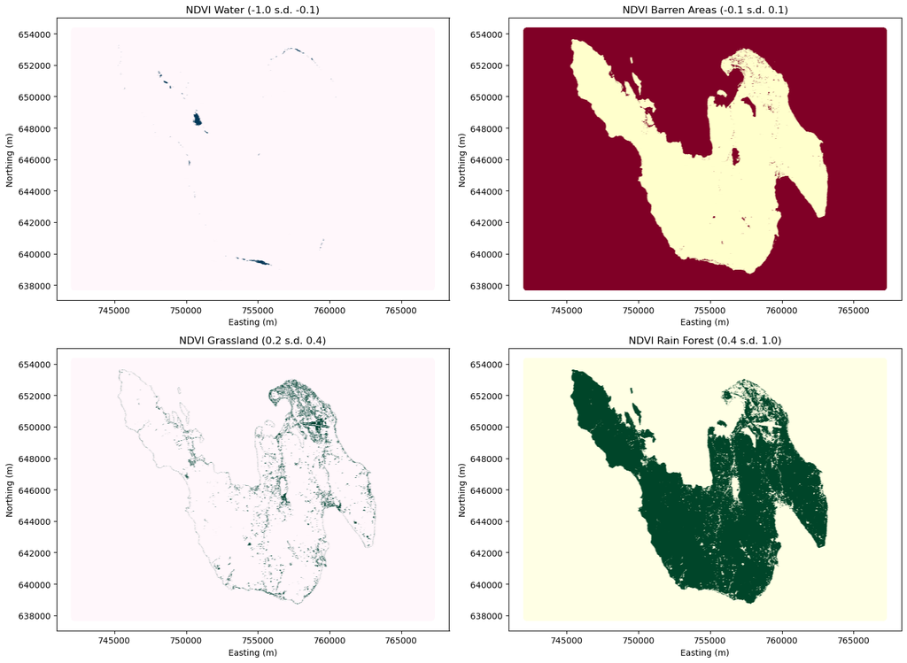

```python
import numpy as np
import rasterio
from rasterio.warp import calculate_default_transform, reproject, Resampling, transform_bounds
import matplotlib.pyplot as plt
from matplotlib.colors import LinearSegmentedColormap, ListedColormap


# Step 1: Read the Raster Data
with rasterio.open('eko.tif') as src:
    red_band = src.read(4)
    nir_band = src.read(8)
    transform = src.transform  # Access the transformation information
    src_crs = src.crs  # Access the source CRS information

# Step 2: Perform NDVI Calculation
# Prevent division by zero
with np.errstate(divide='ignore', invalid='ignore'):
    ndvi = (nir_band.astype(float) - red_band.astype(float)) / (nir_band + red_band)

#Negative values of NDVI (values approaching -1) correspond to water.
#Values close to zero (-0.1to 0.1) generally correspond to barren areas of rock, sand, or snow.
#Low, positive values represent shrub and grassland (approximately 0.2 to 0.4),
#while high values indicate temperate and tropical rainforests (values approaching 1).
# Step 3: Classify NDVI Values
ndvi1 = -1.0
ndvi2 = -0.1
ndvi3 = 0.1
ndvi4 = 0.2
ndvi5 = 0.4
ndvi6 = 1

# Create NDVI classification mask
ndvi_water = np.logical_and(ndvi1 < ndvi, ndvi <= ndvi2)
ndvi_barren_area = np.logical_and(ndvi2 < ndvi, ndvi <= ndvi3)
ndvi_grassland = np.logical_and(ndvi4 <= ndvi, ndvi <= ndvi5)
ndvi_rainforests = np.logical_and(ndvi5 < ndvi, ndvi <= ndvi6)

# Step 5: Plot NDVI in WGS84 Coordinates
# Calculate bounds for the mask
bounds = transform_bounds(src_crs, 'EPSG:4326', *src.bounds)
# Create meshgrid of pixel coordinates
rows, cols = np.indices(ndvi.shape)
# Transform pixel coordinates to WGS84 coordinates
lon, lat = transform * (cols.flatten(), rows.flatten())
# Reshape NDVI to match the pixel coordinates
ndvi_flatten = ndvi.flatten()
# Scatter plot NDVI values in WGS84 coordinates
#plt.scatter(lon, lat, c=ndvi_flatten, cmap='viridis', marker='.', s=1)

# Step 4: Visualize the Result
fig, ax = plt.subplots(2, 2, figsize=(15, 11))
# Plot NDVI Classification
#plt.scatter(lon, lat, c=ndvi_flatten, cmap='viridis', marker='.', s=1)

ax[0,0].scatter(lon, lat, c=ndvi_water, cmap='PuBu')
#imshow(ndvi_water, cmap="PuBu", vmin=-1, vmax=1)
ax[0,0].set_title('NDVI Water (-1.0 s.d. -0.1)')
ax[0,0].set_xlabel('Easting (m)')
ax[0,0].set_ylabel('Northing (m)')

ax[0,1].scatter(lon, lat, c=ndvi_barren_area, cmap='YlOrRd')
#ax[0,1].imshow(ndvi_barren_area, cmap='YlOrBr', vmin=-1, vmax=1)
ax[0,1].set_title('NDVI Barren Areas (-0.1 s.d. 0.1)')
ax[0,1].set_xlabel('Easting (m)')
ax[0,1].set_ylabel('Northing (m)')

ax[1,0].scatter(lon, lat, c=ndvi_grassland, cmap='PuBuGn')
#ax[1,0].imshow(ndvi_grassland, cmap='PuBuGn', vmin=-1, vmax=1)
ax[1,0].set_title('NDVI Grassland (0.2 s.d. 0.4)')
ax[1,0].set_xlabel('Easting (m)')
ax[1,0].set_ylabel('Northing (m)')

ax[1,1].scatter(lon, lat, c=ndvi_rainforests, cmap='YlGn')
#ax[1,1].imshow(ndvi_rainforests, cmap='YlGn', vmin=-1, vmax=1)
ax[1,1].set_title('NDVI Rain Forest (0.4 s.d. 1.0)')
ax[1,1].set_xlabel('Easting (m)')
ax[1,1].set_ylabel('Northing (m)')

plt.tight_layout()
plt.savefig('output_image1.png', bbox_inches='tight')
plt.show()
```